# Assignment 1: Introduction to R

Data Carpentry Contributors, modifications by Mary Alldred

last updated 2023/01/25

# Learning Objectives

> - Explain what R and RStudio are, what they are used for, and how they relate to each other.
> - Describe the purpose of the RStudio script, console, environment, and plots plane.
> - Organize files and directories for a set of analyses as an R Project, and understand the purpose of a working directory.
> - Use Google Drive and Google Desktop to access and modify files from multiple locations.
> - Use the built in RStudio interface and online resources for more information on R functions.
> - Create objects and assign them values in R.
> - Save code in a script file for later use.
> - Use comments to annotate script.
> - Call functions and use arguments to change their default options.
> - Inspect the content of vectors and manipulate their content.
> - Subset and extract values from vectors.

# What is R? What is RStudio?

**R** is a programming language. The term R is typically used to refer to the programming language but can also refer to the software that interprets scripts written using it. **RStudio** is an Integrated Development Environment (IDE) software program. It is a very popular way to interact with R because it organizes your scripts, environment, and output in an easy-to-use way. In the early days, we used simple command line interfaces to interact with R…which was no good, very bad, don’t do it. You can still see what this looks like by launching R (rather than RStudio) from your desktop. Then you can close it, and we can never speak of it again.

## Why are you doing this to me?

The learning curve on R is admittedly steeper than on almost any statistical software, but it is worth learning because the visualizations and analyses you create are free, endlessly customizable, and most importantly **reproducible**.

## Reproducibility

Most forms of statistical software (including ArcGIS) involve a lot of pointing and clicking. This makes them relatively user friendly for simple tasks. Here’s the problem: Think back to the last time you used software (*e.g.*, Excel, Matlab, JMP, SigmaPlot, ArcGIS). How many clicks did it take to produce a single graph? Do you remember every click? (really though?) When you wrote a methods section for your lab report or paper, did you detail every click involved in running your analyses and generating your graphs? If I read your paper and tried to rerun your analysis, would I get every click correct? If you collected more data and needed to rerun your analysis, would you remember every click? **Of course not!**

> R does not involve lots of pointing and clicking, and that’s a good thing!

**Reproducibility** is when someone else (including your future self) can obtain the same results from the same data using the same analysis. R stores your analysis as a series of written commands. So, if you want to redo your analysis because you collected more data, you don’t have to remember which button you clicked in which order to obtain your results. With a stored series of commands (in your script), you can repeat running them, and R will process the new data exactly the same way as before.

An increasing number of journals and funding agencies expect analyses to be reproducible, so knowing R will give you an edge with these requirements.

## Transparency and Accuracy

Working with scripts makes the steps you used in your analysis clear, and the code you write can be inspected by someone else who can give you feedback and spot mistakes.

Working with scripts forces you to have a deeper understanding of what you are doing, and facilitates your learning and comprehension of the methods you use.

Anyone can inspect the source code to see how R works. Because of this transparency, there is less chance for mistakes, and if you (or someone else) find some, you can report and fix bugs.

## Useful Across a Broad Range of Applications

With 10,000+ packages that can be installed to extend its capabilities, R provides a framework that allows you to combine statistical approaches from many scientific disciplines to best suit the analytical framework you need to analyze your data. For instance, R has packages for image analysis, GIS, time series, population genetics, and a lot more.

The skills you learn with R scale easily with the size of your dataset. Whether your dataset has hundreds or millions of lines, it won’t make much difference to you. R is designed for data analysis. It comes with special data structures and data types that make handling of missing data and statistical factors convenient.

R can connect to spreadsheets, databases, and many other data formats, on your computer or on the web.

We will take a tour of the RStudio window, but first, let’s set up your project folder in Google Drive Desktop.

# Setting up a Project Folder in Google Drive Desktop

For this course, we will use your SUNY Plattsburgh Google Drive to save and back-up files. We will create one project folder for weekly course work, and you will set up a separate project folder later for your individual or group class project.

## Logging into Google Drive Desktop

When you log into any school computer, you should see the pop-up window below. If not, you can double click the Google Drive icon on the desktop to launch it. Click “Sign in with browser.”

[figure not shown]

Sign in to Google Drive pop-up window

This will unfortunately launch Microsoft Edge, which is the default browser on these computers. You can change the settings, but they will change back overnight, so there’s really no point. Uncheck all the boxes, select “Continue without data” and then Continue. Type your Plattsburgh email address into the login screen, and choose next.

[figure not shown]

Entering your Plattsburgh email address will redirect you to the campus login. Enter your net ID and password, and complete login using DUO two-factor authentication. I generally choose not to “Trust Browser” if I am working on a public computer.

[figure not shown]

At this point, the browser will remind you to make sure you have installed the Google Drive app, which we have. So select “Sign in” to complete the process. If you plan on working from your home computer, you should make sure you download the Google Drive app to access your files in R.

[figure not shown]

## Create a Project Folder on the `G:\` Drive

At this point, you can close the Browser, and click the Drive icon on the desktop to open your Google Drive folder. This `G:\` drive gives you access to all the files stored on your Google Drive, and any shared Drives that you have access to. We will set up your class project folder in your `My Drive`.

(Note that the `Shared drives` folder will be a powerful tool for collaboration when working on your group project or with your research advisor in the future!)

[figure not shown]

Google Drive (G:) in File Explorer

Open your `My Drive` and create a new folder called “Environmental Data Analysis”

# Creating a New Project in RStudio

Now that you have created a project folder, let’s open RStudio and create a new project.

## Why use projects?

It is good practice to keep data, analyses, images, and text in a single folder, called the **working directory**. Any scripts you write and save in this folder can then use relative paths to files that indicate where inside the project folder a file is located (as opposed to absolute paths, which point to where a file is on a specific computer). This allows you to move your project folder around on your computer, or to other computers (*e.g.*, work and home) and share it with others without worrying about whether or not your code will still work.

> Setting up a project file, and opening your project file *each time* you code in R is **absolutely critical** because it will ensure that R looks for your files, and saves files, in the right place!

## How to create a new project

Open RStudio. Under the `File` menu, choose `New Project`. This will launch the pop-up menu below.

[figure not shown]

Because you already have a folder on your `G:\` that you want to use, we will choose the second option, `Existing Directory`. This will launch the following pop-up:

[figure not shown]

Click `Browse` and navigate to your `Environmental Data Analysis` folder. Then click `Create Project`.

## Organizing the Project Folder

For this workshop, we will need a `data_raw/` folder to store our raw data, and we will use `data/` for when we learn how to export data as CSV files, and a `fig/` folder for the figures that we will save. You can create folders directly from RStudio by clicking in the File panel on the bottom right corner of your screen. Use this to create three folders named `data_raw`, `data`, and `fig`.

When you open your GoogleDrive folder on the Desktop, you should see that those three folders and your project file now exist in your `Environmental Data Analysis` folder. Note that you could also create folders and save files directly in your Google Drive. As you move forward in this class, you may decide that you want to create additional folders like `workshops` to save the html workshop files like the one you’re using right now.

# Tour of RStudio

Now that we’ve set up your project folder, let’s take a step back and look at the RStudio environment that you’re going to be working in. Click on the icon and select `R Script`. This will provide you with a workspace where you can type and save code. You can also open a new script by typing `Ctrl` + `Shift` + `N`. Once you have opened a new script, you should see four main panels in your RStudio window:

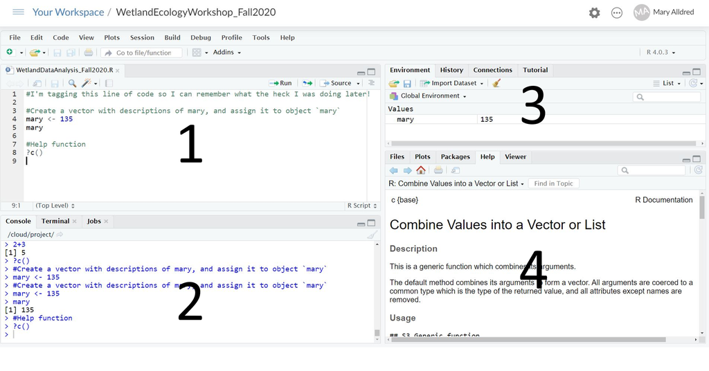

1. The script
2. The console
3. The environment
4. A panel with Files, Plots, Packages, Help, and Viewer

## The script

The basis of programming is that we write down instructions for the computer to follow, and then we tell the computer to follow those instructions. We write, or *code*, instructions in R because it is a common language that both the computer and we can understand (most of the time). We call the instructions *commands* and we tell the computer to follow the instructions by *executing*, or *running* those commands.

There are two main ways of interacting with R: by using the console or by using script files (plain text files that contain your code). Because we want our code and workflow to be reproducible, it is better to type the commands we want in the script editor, and save the script. This way, there is a complete record of what we did, and anyone (including our future selves!) can easily replicate the results on their computer.

You can think of the script as your work space. Here, you can enter, run, and save code. I recommend you **never delete** any code that works from your script. You can always copy and paste code and then make changes.

It is good practice to leave space between code chunks and tag lines using a `#`. R will skip lines that begin with `#` when running code. You can run any line of code by placing your cursor on the line and typing `Ctrl` + `Enter`.

```r
# I have tagged this line of code so that I can remember what I was doing when I come back to this project later!
```

Go ahead and **save** your script now. Hit `Ctrl` + `s`. You will notice that this opens your project folder. Save your script as something sensible, *e.g.*, “A01 Intro to R”. This will save your script as a .R file, which you can save and reopen at any time. Notice that if you have unsaved changes in your script, the title on the tab will appear in red with a * at the end of the file name. When you save changes (`Ctrl` + `s`), the title will appear black again. It’s good practice to save your changes at the end of a code block or every ~15 min.

## The console

The console pane (in RStudio, the bottom left panel) is the place where commands written in the R language can be typed and executed immediately by the computer. It is also where the results will be shown for commands that have been executed. You can type commands directly into the console and press Enter to execute those commands, but they will be forgotten when you close the session.

When you run code from a script, you will see the code and the output appear in the console. Code that has run will show up in blue (default). Warnings, errors, and messages will show up in red. Output will show up in black.

## The environment

The environment will show a list of any objects or functions that you create (more on this in a bit). In R, we create objects by giving them a name, and then using `<-` to assign something to that name. For example, in the code below, I create an object named `mary` and assign the number 135 (my office number in Hudson) to the object.

```r
mary <- 135
mary
```

```
## [1] 135
```

Once I have created this object, it shows up in my Environment panel as object `mary`. I can call that object by typing the object name `mary`, and hitting `Ctrl` + `Enter`. When you run this code, you should see the output `135` appear in the console.

## Files, Plots, Packages, Help, Viewer

The **Files** panel shows you all of the folders and files in your project. The **Plots** panel shows plots that you create. You can use the arrow buttons to revisit previous plots. The **Packages** panel shows a list of packages that you have installed. Packages contain additional functions programmers have written that can help you to tidy your data, make pretty graphs, or run more complicated analyses. You can install and update packages here, or attach and detach packages from your project. However, it is best practice to install and load packages from your *script* so that you will have a record of packages that you need to run your code. We will cover how to install and load a package later in this course. The **Help** panel will display help files. This tool is very useful for exploring options for functions that you use, or for help in interpreting output. Type `?c()` into your script and run it to pull up the help file for the concatenate function, which we will use later in this workshop.

# Creating objects in R

You can get output from R simply by typing math in the script and running it:

```r
3 + 5
12 / 7
```

However, to do useful and interesting things, we need to assign values to objects. To create an **object**, we need to give it a name followed by the assignment operator `<-`, and the value we want to give it:

```r
weight_kg <- 55
```

`<-` is the assignment operator. It assigns values on the right to objects on the left. So, after executing `x <- 3`, the value of `x` is `3`. For historical reasons, you can also use `=` for assignments, but not in every context. Because of the slight differences in syntax, it is good practice to always use `<-` for assignments.

In RStudio, typing `Alt` + `-` will write `<-` in a single keystroke in a PC, while typing `Option` + `-` does the same in a Mac.

## Naming objects

Objects can be given almost any name such as `x`, `current_temperature`, or `subject_id.` Here are some further guidelines on naming objects:

- You want your object names to be explicit and not too long.
- They cannot start with a number (`2x` is not valid, but `x2` is).
- R is case sensitive, so for example, `weight_kg` is different from `Weight_kg`.
- There are some names that cannot be used because they are the names of fundamental functions in R (*e.g.*, `if`, `else`, `for`). In general, even if it’s allowed, it’s best to not use other function names (*e.g.*, `c`, `T`, `mean`, `data`, `df`, `weights`). If in doubt, check the help to see if the name is already in use.
- It’s best to avoid dots (`.`) within names. Many function names in R itself have them and dots also have a special meaning in R and other programming languages. To avoid confusion, don’t include dots in names.
- It is recommended to use nouns for object names and verbs for function names.
- Be consistent in the styling of your code, such as where you put spaces, how you name objects, etc. Styles can include “lower_snake”, “UPPER_SNAKE”, “lowerCamelCase”, “UpperCamelCase”, etc. Using a consistent coding style makes your code clearer to read for your future self and your collaborators.

## Using objects

When assigning a value to an object, R does not print anything. You can make R print the value by typing the object name:

```r
weight_kg <- 55    # doesn't print anything to console
weight_kg          # prints value of `weight_kg`
```

Now that R has `weight_kg` in memory, we can do math with it. For instance, we may want to convert this weight into pounds (weight in pounds is 2.2 times the weight in kg):

```r
2.2 * weight_kg
```

We can also change an object’s value by assigning it a new one:

```r
weight_kg <- 57.5
2.2 * weight_kg
```

This means that assigning a value to one object does not change the values of other objects. For example, let’s store the animal’s weight in pounds in a new object, `weight_lb`:

```r
weight_lb <- 2.2 * weight_kg
```

and then change weight_kg to 100.

```r
weight_kg <- 100
```

What do you think is the current content of the object weight_lb? 126.5 or 220? What happens if you run the `weight_lb <- 2.2 * weight_kg` line of code again?

# Comments

At this point, I want to reemphasize the importance of annotating your code using comments. The comment character in R is `#`. Anything to the right of a `#` in a script will be ignored by R. It is useful to leave notes and explanations in your scripts. This is a great tool for keeping notes as you work through this class! It is also good practice to keep notes so that you can remember what you were doing when you return to your code in the future, and so collaborators can understand what your code is doing (and help you fix it if it’s not doing that thing).

Commenting can also be useful if you want to save code that you need to run once, but you don’t want to accidentally re-run it (*e.g.*, code you used to install a package, or a plot that you made but don’t want to use). For convenience, RStudio provides a keyboard shortcut to comment or uncomment a paragraph: after selecting the lines you want to comment, press at the same time on your keyboard `Ctrl` + `Shift` + `C`. If you only want to comment out one line, you can put the cursor at any location of that line (*i.e.*, no need to select the whole line), then press `Ctrl` + `Shift` + `C`.

```r
# I am using this line to explain what my code did
mary <- 135     # this assigns my office number to object mary

# I could use this line to install the tidyverse package
# but I don't want to do that every time I run my code:
# install.packages("tidyverse")
```

> Remember to annotate your code using **comments** so other coders (including your future self) can understand your process!

# Functions and arguments

**Functions** are “canned scripts” that automate more complicated sets of commands including mathematical operations, variable assignments, etc. Many functions are predefined, or can be made available by importing R packages (more on that later). A function usually takes one or more inputs called **arguments**, separated by commas. Functions often (but not always) return a value. A typical example would be the function `sqrt()`. The input (the argument) must be a number, and the return value (in fact, the output) is the square root of that number. Executing a function (‘running it’) is called **calling** the function. An example of a function call is:

```r
weight_kg <- sqrt(10)
```

Here, the value of 10 is given to the `sqrt()` function, the `sqrt()` function calculates the square root, and returns the value which is then assigned to the object `weight_kg`. This function takes one argument, other functions might take several.

The return ‘value’ of a function need not be numerical (like that of `sqrt()`), and it also does not need to be a single item. It can be a set of things, or even a dataset. We’ll see that when we read data files into R.

Arguments can be anything, not only numbers or filenames, but also other objects. Exactly what each argument means differs from function to function, and must be looked up in the documentation (see below). Some functions take arguments which may either be specified by the user, or, if left out, take on a default value: these are called **options**. Options are typically used to alter the way the function operates, such as whether it ignores ‘bad values’, or what symbol to use in a plot. However, if you want something specific, you can specify a value of your choice which will be used instead of the default.

Let’s try a function that can take multiple arguments: `round()`.

```r
round(3.14159)
```

```
## [1] 3
```

Here, we’ve called `round()` with just one argument, `3.14159`, and it has returned the value `3`. That’s because the default is to round to the nearest whole number. If we want more digits we can see how to do that by getting information about the round function. We can use `args(round)` to find what arguments it takes, or look at the help for this function using `?round`.

```r
args(round)
?round
```

We see that if we want a different number of digits, we can type `digits = 2` or however many we want.

```r
round(3.14159, digits = 2)
```

```
## [1] 3.14
```

If you provide the arguments in the exact same order as they are defined you don’t have to name them:

```r
round(3.14159, 2)
```

This practice is more typical for functions you use so often that you remember the order of the arguments. If you do name the arguments, you can switch their order, and the function still works fine.

```r
round(digits = 2, x = 3.14159)
```

It’s good practice to put the non-optional arguments (like the number you’re rounding) first in your function call, and to then specify the names of all optional arguments. If you don’t, someone reading your code might have to look up the definition of a function with unfamiliar arguments to understand what you’re doing.

# Vectors and data types

A **vector** is the most common and basic data type in R, and is pretty much the workhorse of R. A vector is composed of a series of values, which can be either numbers or characters. We can assign a series of values to a vector using the concatenate function `c()`. For example we can create a vector of animal weights and assign it to a new object `weight_g`:

```r
weight_g <- c(50, 60, 65, 82)
weight_g
```

A vector can also contain characters:

```r
animals <- c("mouse", "rat", "dog")
animals
```

The quotes around “mouse”, “rat”, etc. are *essential* here. Without the quotes R will assume objects have been created called `mouse`, `rat` and `dog.` As these objects don’t exist in R’s memory, there will be an error message.

## Inspecting data

There are many functions that allow you to inspect the content of a vector. `length()` tells you how many elements are in a particular vector:

```r
length(weight_g)
length(animals)
```

An important feature of a vector, is that all of the elements are the same type of data. The function `class()` indicates what kind of object you are working with:

```r
class(weight_g)
class(animals)
```

The function `str()` provides an overview of the structure of an object and its elements. It is a useful function when working with large and complex objects:

```r
str(weight_g)
str(animals)
```

## Adding data to an object

You can use the `c()` function to add other elements to your vector:

```r
weight_g <- c(weight_g, 90) # add to the end of the vector
weight_g <- c(30, weight_g) # add to the beginning of the vector
weight_g
```

In the first line, we take the original vector `weight_g`, add the value `90` to the end of it, and save the result back into `weight_g.` Then we add the value `30` to the beginning, again saving the result back into `weight_g.`

We can do this over and over again to grow a vector, or assemble a dataset. As we program, this may be useful to add results that we are collecting or calculating.

## Types of vectors

An **atomic vector** is the simplest R data type and is a linear vector of a single type. Above, we saw 2 of the 6 main atomic vector types that R uses: `"character"` and `"numeric"`. These are the basic building blocks that all R objects are built from. The other 4 atomic vector types are:

- `"logical"` for TRUE and FALSE (the boolean data type)
- `"integer"` for integer numbers (*e.g.*, 2L, the L indicates to R that it’s an integer)
- `"complex"` to represent complex numbers with real and imaginary parts (*e.g.*, 1 + 4i) and that’s all we’re going to say about that (doesn’t come up a lot in data analysis with real data)
- `"raw"` for bitstreams that we won’t discuss further

You can check the type of your vector using the `typeof()` function and inputting your vector as the argument.

Vectors are one of the many **data structures** that R uses. Other important ones are lists (`list`), matrices (`matrix`), data frames (`data.frame`), factors (`factor`) and arrays (`array`).

# Indexing data

## Subsetting vectors

If we want to extract one or several values from a vector, we must provide one or several indices in square brackets. For instance:

```r
animals <- c("mouse", "rat", "dog", "cat")
# Extract the second value from the animals vector
animals[2]
```

```
## [1] "rat"
```

```r
# Extract the third and second values from the animals vector
animals[c(3, 2)]
```

```
## [1] "dog" "rat"
```

R indices start at 1. Programming languages like Fortran, MATLAB, Julia, and R start counting at 1, because that’s what human beings typically do. Languages in the C family (including C++, Java, Perl, and Python) count from 0 because that’s simpler for computers to do.

## Conditional subsetting

Another common way of subsetting is by using a logical vector. `TRUE` will select the element with the same index, while `FALSE` will not:

```r
weight_g <- c(21, 34, 39, 54, 55)
weight_g[c(TRUE, FALSE, FALSE, TRUE, TRUE)]
```

```
## [1] 21 54 55
```

Typically, these logical vectors are not typed by hand, but are the output of other functions or logical tests. For instance, if you wanted to select only the values above 50:

```r
# will return logicals with TRUE for the indices that meet the condition
weight_g > 50
```

```
## [1] FALSE FALSE FALSE  TRUE  TRUE
```

```r
# so we can use this to select only the values above 50
weight_g[weight_g > 50]
```

```
## [1] 54 55
```

You can combine multiple tests using `&` (both conditions are true, AND) or `|` (at least one of the conditions is true, OR):

```r
weight_g[weight_g > 30 & weight_g < 50]
```

```
## [1] 34 39
```

```r
weight_g[weight_g <= 30 | weight_g == 55]
```

```
## [1] 21 55
```

```r
weight_g[weight_g >= 30 & weight_g == 21]
```

```
## numeric(0)
```

Here, `>` stands for “greater than”, `<` for “less than”, `<=` for “less than or equal to”, and `==` for “equal to”. The double equal sign `==` is a test for numerical equality between the left and right hand sides, and should not be confused with the single `=` sign, which performs variable assignment (similar to `<-`).

A common task is to search for certain strings in a vector. One could use the “or” operator `|` to test for equality to multiple values, but this can quickly become tedious. The function `%in%` allows you to test if any of the elements of a search vector are found:

```r
animals <- c("mouse", "rat", "dog", "cat", "cat")

# return both rat and cat
animals[animals == "cat" | animals == "rat"]
```

```
## [1] "rat" "cat" "cat"
```

```r
# return a logical vector that is TRUE for the elements within animals
# that are found in the character vector and FALSE for those that are not
animals %in% c("rat", "cat", "dog", "duck", "goat", "bird", "fish")
```

```
## [1] FALSE  TRUE  TRUE  TRUE  TRUE
```

```r
# use the logical vector created by %in% to return elements from animals
# that are found in the character vector
animals[animals %in% c("rat", "cat", "dog", "duck", "goat", "bird", "fish")]
```

```
## [1] "rat" "dog" "cat" "cat"
```

# Missing data

As R was designed to analyze datasets, it includes the concept of missing data (which is uncommon in other programming languages). Missing data are represented in vectors as `NA`.

When doing operations on numbers, most functions will return `NA` if the data you are working with include missing values. This feature makes it harder to overlook the cases where you are dealing with missing data. You can add the argument `na.rm = TRUE` to calculate the result as if the missing values were removed (`rm` stands for ReMoved) first. Try each of the following operations for vector `heights` that includes a missing value, and note the differences in output:

```r
heights <- c(2, 4, 4, NA, 6)
mean(heights)
max(heights)
mean(heights, na.rm = TRUE)
max(heights, na.rm = TRUE)
```

If your data include missing values, which data nearly always do, you may want to become familiar with the functions `is.na()`, `na.omit()`, and `complete.cases()`. See below for examples.

```r
## Extract those elements which are not missing values.
heights[!is.na(heights)]

## Returns the object with incomplete cases removed.
#The returned object is an atomic vector of type `"numeric"`.
na.omit(heights)

## Extract those elements which are complete cases.
#The returned object is an atomic vector of type `"numeric"`.
heights[complete.cases(heights)]
```

Now that we have learned how to write scripts, and the basics of R’s data structures, we are ready to start working with real datasets. In the next unit, we will use the Portal dataset to apply these concepts to data frames.

# Assignment

The assignment this week contains two parts. Part one reviews the statistical tests that we covered in our first meeting. Part two reviews the concepts from this R workshop. The best way to complete part two is to try running the code in R. If you have time, I recommend you complete part two before leaving the workshop today!

### Part 1: Selecting Appropriate Tests

For each of the following questions/objectives, select the best statistical test to analyze the data. (For now, assume that the data will meet the assumptions of the tests.)

1. Compare soil carbon content of 20 soil samples collected in a burned watershed to 20 soil samples collected in a control/reference watershed.
2. Test the hypothesis that male and female fish will be equally abundant inside and outside of marine protected areas.
3. Can the percent-cover of a species of marine phytoplankton be used to predict salinity in surface water?
4. Is the height of red oak trees related to the root mass of red oak trees?
5. Determine whether percent seed germination at 30ºC differs for marsh-grass seeds collected from populations in Florida, South Carolina, Maryland, and Maine.
6. Compare total aboveground biomass of 10 forest plots that have been subjected to clear-cutting for the past 25 years and 10 forest plots where selective logging has been implemented for the past 25 years.
7. Determine whether the prevalence of avian influenza in shorebirds is related to annual ocean temperatures.
8. Determine whether microplastic export from sewage wastewater differed before and after implementation of a new removal process.
9. Determine whether a new screening tool is effective in capturing five different categories of microplastics (*e.g.*, fiber, film, etc.)
10. Test the null hypothesis that the number of humans captured on trail cameras should be independent of the number of wildlife specimens captured on trail cameras for four different locations on the Saranac River Trail.

### Part 2: Introduction to R

The following questions will review basic vocabulary and functionality of the programming language R. We will be using this vocabulary throughout the semester.

11. Which of the following statements assigns the number `3` to an object named `three`?
    - `3 <- three`
    - `three <- 3`
    - `3 <- "three"`
    - `"three" <- 3`
12. What will be the output if I call the object `mass_index` after executing the following lines of code?  
    `mass <- 30`  
    `age <- 3`  
    `mass <- mass * 2`  
    `age <- age + 1`  
    `mass_index <- mass/age`
13. Which of the following lines of code includes a function with two arguments? (More than one answer may be correct)
    - `mean(mass, na.rm = T)`
    - `mean(mass)`
    - `round(3.14159, digits = 2)`
    - `round(3.14159)`
    - `c(2, 3)`
14. Which of the following lines of code will create an object that is a character vector? (More than one answer may be true.)
    - `vec <- c(1, 2, 3, 4)`
    - `vec <- c(1, 2, 3, "red")`
    - `vec <- c("red", "orange", "yellow", "green")`
    - `vec <- c(T, F, T, F)`
    - `vec <- c(T, F, T, "F")`
15. Which of the following lines of code will return the value `"cat"` from the vector `animals` (below)? (More than one answer may be true.)  
    `animals <- c("dog", "cat", "mouse", "rat", "platypus")`
    - `animals[2]`
    - `animals(2)`
    - `animals["cat"]`
    - `animals[animals == "cat"]`
    - `animals(animals == "cat")`
16. Which of the following lines of code would create a new object, `heights_no_na`, that excludes any missing values from the vector `heights` (below). (More than one answer may be true.)  
    `heights <- c(63, 69, 60, 65, NA, 68, 61, 70, 61, 59, 64, 69, 63, 63, NA, 72, 65, 64, 70, 63, 65)`
    - `heights_no_na <- heights[!is.na(heights)]`
    - `heights_no_na <- heights[complete.cases(heights)]`
    - `heights_no_na <- !is.na(heights)`
    - `heights_no_na <- complete.cases(heights)`
    - `heights_no_na <- na.omit(heights)`